# A Map of Mental Illness in America

Nina Tran, Adrian Fernandez, Caroline Low, and Morgan Bryson

2/17/2021

# Introduction

Mental illness is pervasive across America in all demographic groups. It is an issue that effects millions of people every year, having a lasting impact on overall health and well-being. *But how does mental illness effect specific demographics?* Our team sought to investigate how mental illness is distributed in America based on different demographic characteristics. This research is crucial in identifying disproportional mental health services and treatment. Revealing inequalities in mental illness prevalence can also point to larger, systemic issues within our country that we must solve to better support our citizens.

We will be using data sets from multiple sources to illustrate our points. The primary data sets being used for our analyses are from the **Substance Abuse and Mental Health Services Administration (SAMHA)** and the **Unemployment and Mental Illness Survey**. The SAMHA data set is a collection of clients who received services from state mental health agencies in 2018. We will also be using the SAMHA National Mental Health Services Survey from 2018. This data set breaks down mental health services and facilities in each state. Finally, we used a data set on [Kaggle](https://www.kaggle.com/michaelacorley/unemployment-and-mental-illness-survey), that focused on mental illness prevalence and unemployment. This data was collected by Michael Corley in a paid research study.

## Summary

Total Number of People Endorsing a Mental Illness by Race

|  | American Indian/Alaskan Native | Asian | Black | Native Hawaiian/Pacific Islander | White | Other/Multiracial |
| --- | --- | --- | --- | --- | --- | --- |
| RACE | American Indian/Alaska Native | Asian | Black or African American | Native Hawaiian or Other Pacific Islander | White | Another race alone or two or more races |
| Number_of_Mental_Health_Diagnoses_Reported | 60796 | 41553 | 736971 | 9837 | 2598146 | 284496 |
| Trauma_or_stressor_related_disorder_reported | 12356 | 6136 | 90334 | 1845 | 365286 | 43037 |
| Anxiety_disorder_reported | 10120 | 6573 | 71361 | 1492 | 444805 | 40973 |
| ADHD_reported | 3774 | 1582 | 73696 | 493 | 202623 | 27728 |
| Counduct_disorder | 835 | 288 | 15389 | 121 | 30986 | 5844 |
| Delirium_Dementia_disorder | 184 | 187 | 1741 | 26 | 6165 | 515 |
| Bipolar_disorder | 4402 | 2617 | 63990 | 727 | 269108 | 21615 |
| Depressive_disorder | 13786 | 11201 | 148734 | 2345 | 583297 | 58150 |
| Oppositional_Defiant_disorder | 1138 | 243 | 26323 | 127 | 54168 | 9794 |
| Schizophrenia_disorder | 4020 | 6098 | 123571 | 1121 | 193469 | 22873 |
| Alcohol_or_substance_related_disorder | 1439 | 370 | 18101 | 269 | 68652 | 6341 |

Total Number of People Endorsing a Mental Illness by Gender

| GENDER | Male | Female |
| --- | --- | --- |
| Number_of_Mental_Health_Diagnoses_Reported | 1752691 | 1978720 |
| Trauma_or_stressor_related_disorder_reported | 207514 | 311443 |
| Anxiety_disorder_reported | 220100 | 355188 |
| ADHD_reported | 207020 | 102868 |
| Counduct_disorder | 38121 | 15338 |
| Delirium_Dementia_disorder | 4912 | 3906 |
| Bipolar_disorder | 144165 | 218267 |
| Depressive_disorder | 308985 | 508460 |
| Oppositional_Defiant_disorder | 62168 | 29618 |
| Schizophrenia_disorder | 217827 | 133294 |
| Alcohol_or_substance_related_disorder | 53301 | 41757 |

Total Number of People Endorsing a Mental Illness by Age Range

|  | 0-11 Years Old | 12-14 Years Old | 15-17 Years Old | 18-20 Years Old | 21-24 Years Old | 25-29 Years Old | 30-34 Years Old | 35-39 Years Old | 40-44 Years Old | 45-49 Years Old | 50-54 Years Old | 55-59 Years Old | 60-64 Years Old | 65 Years and Older |
| --- | --- | --- | --- | --- | --- | --- | --- | --- | --- | --- | --- | --- | --- | --- |
| AGE | 0-11 years old | 12-14 years old | 15-17 years old | 18-20 years old | 21-24 years old | 25-29 years old | 30-34 years old | 35-39 years old | 40-44 years old | 45-49 years old | 50-54 years old | 55-59 years old | 60-64 years old | 65 years and older |
| Number_of_Mental_Health_Diagnoses_Reported | 421990 | 264293 | 287988 | 171651 | 214994 | 339407 | 331372 | 314148 | 261491 | 273052 | 282375 | 257639 | 167575 | 143824 |
| Trauma_or_stressor_related_disorder_reported | 93448 | 44722 | 43235 | 22234 | 26832 | 44433 | 44955 | 42969 | 34992 | 34847 | 32920 | 26502 | 15082 | 11823 |
| Anxiety_disorder_reported | 46618 | 33831 | 43579 | 28971 | 36511 | 59229 | 58017 | 53369 | 43265 | 43853 | 43811 | 38715 | 24872 | 20683 |
| ADHD_reported | 125793 | 62428 | 44793 | 16320 | 10786 | 12847 | 10383 | 8113 | 5232 | 4465 | 3489 | 2781 | 1548 | 918 |
| Counduct_disorder | 24231 | 9981 | 10341 | 2754 | 1241 | 1265 | 906 | 706 | 465 | 431 | 406 | 319 | 215 | 202 |
| Delirium_Dementia_disorder | 156 | 153 | 198 | 128 | 202 | 342 | 365 | 426 | 425 | 612 | 785 | 1020 | 974 | 3032 |
| Bipolar_disorder | 2678 | 4909 | 9774 | 13457 | 23554 | 41190 | 43026 | 43133 | 36918 | 38684 | 37866 | 32683 | 19727 | 14860 |
| Depressive_disorder | 18037 | 39188 | 64821 | 43569 | 52209 | 79292 | 76000 | 71853 | 62760 | 69997 | 76942 | 72754 | 48241 | 41850 |
| Oppositional_Defiant_disorder | 41156 | 24652 | 19783 | 4012 | 1010 | 470 | 245 | 151 | 80 | 53 | 50 | 35 | 23 | 73 |
| Schizophrenia_disorder | 986 | 1414 | 3085 | 7424 | 19313 | 34478 | 36429 | 37863 | 32693 | 35137 | 40599 | 42505 | 31004 | 28222 |
| Alcohol_or_substance_related_disorder | 155 | 670 | 3631 | 3812 | 7544 | 14235 | 14412 | 12935 | 9501 | 8575 | 8016 | 6575 | 3407 | 1704 |

# Analyses

## Mental Illness Proportions

We looked at the proportion of clients with different mental illnesses grouped by rates. The bar graph illustrates the prevalence of each mental illness recorded within each demographic. It is important to note that this represents each client’s **primary mental illness**. Many people had more than one mental illness, but due to insufficient data, we decided to only look at the primary reason for treatment. The chart illuminated various patterns in the prevalence of mental illnesses within different races. African Americans had the highest rates of ADD/ADHD, Conduct Disorder, and Oppositional Defiant Disorder (ODD). African Americans were also treated less often for anxiety and trauma-related disorders than all other races. It is important to think critically about why certain mental illnesses are disproportionately represented in different races. Certain groups could be overdiagnosed due to biases and cultural differences. The reverse could also occur; groups could be underdiagnosed because of stigmas surrounding a certain mental illness or structural oppression. In order to reach equitable mental healthcare for all, we need to understand these patterns in diagnoses and treatment.

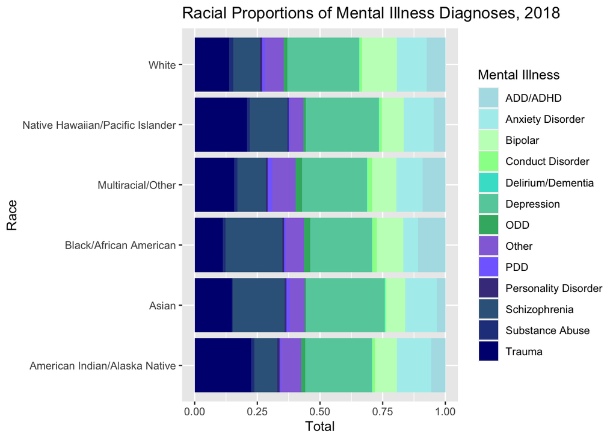

## Intersections of Unemployment, Gender, and Mental Health

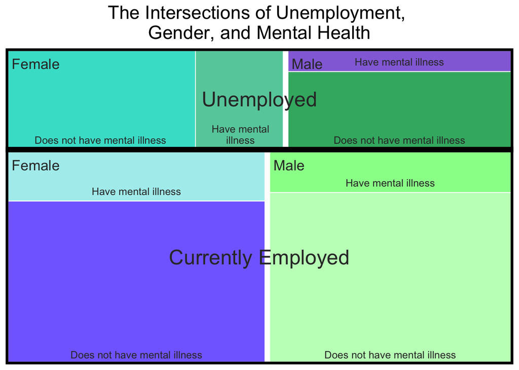

## Distribution of Mental Health Facilities

The map below illustrates the number of mental health facilities in each state (excluding Alaska and Hawaii). We wanted to investigate how mental health facilities were distributed in America because this is an indicator of how accessible mental health services are in the country. As shown on the map, only a few states exceeded 600 facilities in 2018. Most of the Midwestern region has limited access to mental health services compared to the rest of America. One conclusion we can draw from this is that people located in these regions will have a harder time getting help for mental illness. There could be regional differences as well in how mental illness is stigmatized, resulting in higher or lower numbers of mental health facilities.

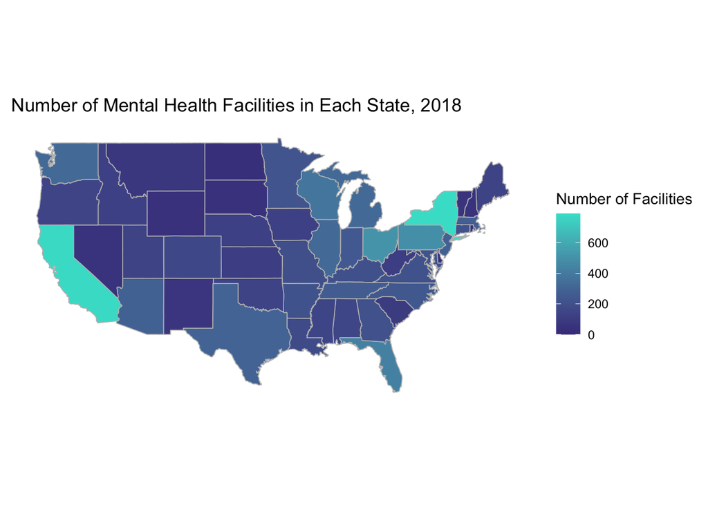